# DM Report

2022-12-06

## Importing and Wrangling the Data

The dataset is saved as a number of json objects, we use the jsonlite package to read in the data as a dataframe.

```r
library("jsonlite")
library(magrittr)

comments.df <-  stream_in(file("http://files.pushshift.io/reddit/comments/sample_data.json"))
```

```
## opening url input connection.
```

[output not shown]

```
## closing url input connection.
```

```r
attach(comments.df)

#head(comments.df)
```

Most of the data and NA cells populated correctly, but some need to be adjusted first.

Some of the values populated as a blank character (““) and some populated as NA values. Replace all blank characters so that they read as NA values instead.

```r
comments.df[comments.df==""] <- NA
```

The author_cakeday column is full of NA or True values, adjust this to be true and false.

```r
comments.df[is.na(author_cakeday), "author_cakeday" ] <- FALSE
```

We may want to work only with the comments that are still available, and filter out deleted or removed comments. The data frame not.deleted consists of only comments which have a valid (that is, not deleted or removed) comment body.

```r
not.deleted <- comments.df[body != "[deleted]" & body != "[removed]",]
```

## Data quality analysis

The following function gets the proportion of completed entries in a given data frame column.

```r
get.completeness <- function(df_col){
  total <- length(df_col)
  incomplete <- 0

  empty.values <- list("", " ", "?", "NULL", "null", "NA", "N/A", "[Not Available]")

  for (i in 1:length(df_col)){
    cell <- df_col[i]
    if (cell %in% empty.values | is.na(cell) )
      incomplete <- incomplete +1
  }

  return( paste("Completion rate:", 1 - (incomplete/total)))
}

null.checks <- list(distinguished, author_flair_css_class, author_flair_text, author_cakeday)
lapply(null.checks, get.completeness)
```

```
## [[1]]
## [1] "Completion rate: 0.0204"
##
## [[2]]
## [1] "Completion rate: 0.2705"
##
## [[3]]
## [1] "Completion rate: 0.2565"
##
## [[4]]
## [1] "Completion rate: 0.00480000000000003"
```

This modified version of the completeness function checks how many entries of a column have been deleted or removed (particularly, for the author and body columns).

```r
check.deleted <- function(col){
  total <- length(col)
  deleted <- 0

  deleted.list <- list("[deleted]", "[removed]")

  for (i in 1:length(col)){
    cell <- col[i]
    if (cell %in% deleted.list | is.na(cell) )
      deleted <- deleted +1
  }

  return( paste("Deletion rate:", (deleted/total)))

}

deleted.checks <- list(author, body)

lapply(deleted.checks,check.deleted)
```

```
## [[1]]
## [1] "Deletion rate: 0.0779"
##
## [[2]]
## [1] "Deletion rate: 0.0707"
```

## Plots and Graphics

### Score vs Controversiality

#### Score vs Contr. Scatterplot

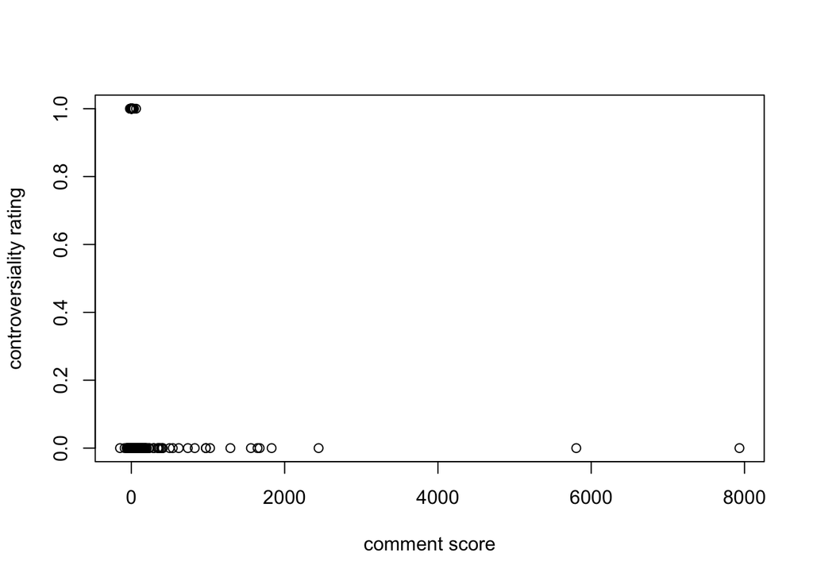

```r
plot(score, controversiality,
     xlab = "comment score",
     ylab = "controversiality rating")
```

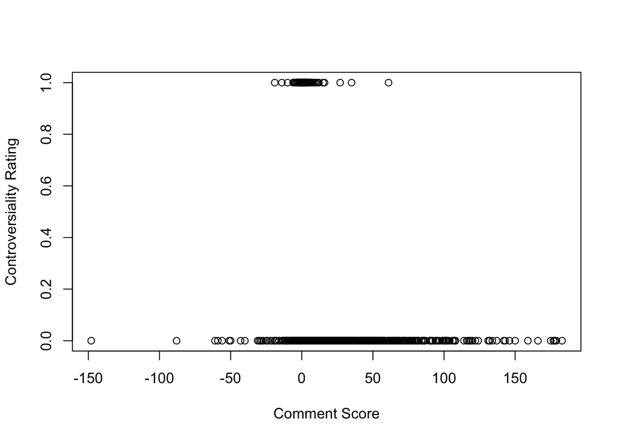

```r
plot(score[score<200], controversiality[score<200],
     xlab = "Comment Score",
     ylab = "Controversiality Rating")
```

#### Score Boxplot / Boxplot by controversiality

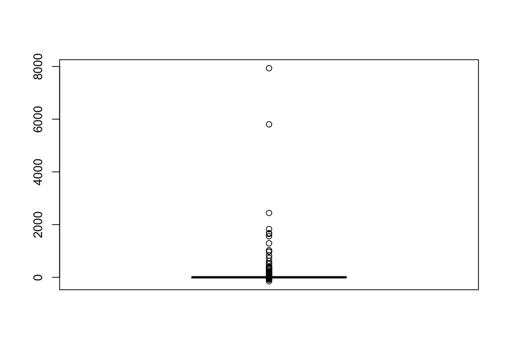

```r
boxplot(score)
```

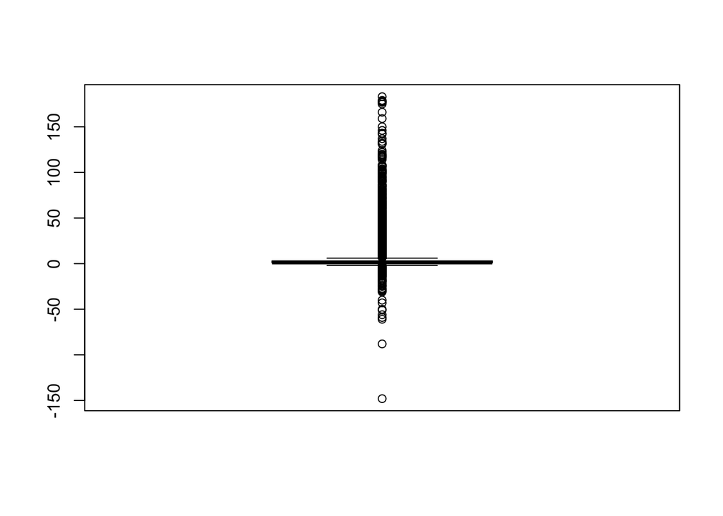

```r
boxplot(score[score < 200])
```

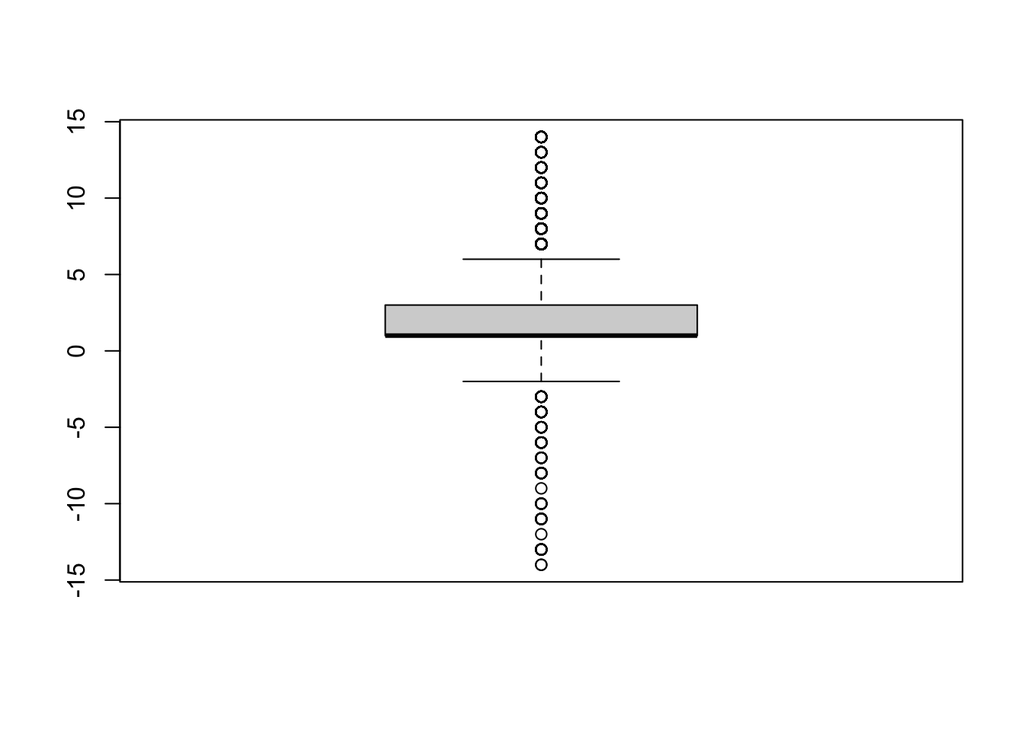

```r
boxplot(score[abs(score)< 15])
```

```r
summary(score)
```

```
##    Min. 1st Qu.  Median    Mean 3rd Qu.    Max.
## -148.00    1.00    1.00    8.11    3.00 7934.00
```

A look at the frequency table shows that the most commonly occurring comment scores are in the range of [0,9].

```r
library("dplyr")
#View(table(data$score))

scores.freq <- table(score) %>%
  as.data.frame() %>%
  arrange(desc(Freq))

head(scores.freq, n=10)
```

```
##    score Freq
## 1      1 4419
## 2      2 1599
## 3      3  894
## 4      5  351
## 5      4  348
## 6      0  314
## 7      6  263
## 8      7  202
## 9      8  133
## 10     9  118
```

#### Score vs Contr.Vioplots

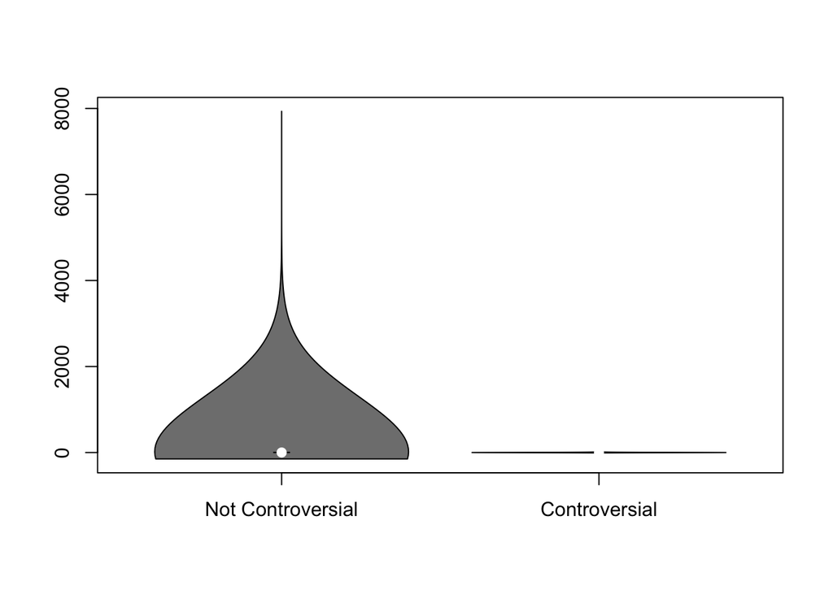

```r
library(vioplot)
vioplot(score[controversiality==0], score[controversiality==1], names=c("Not Controversial", "Controversial"))
```

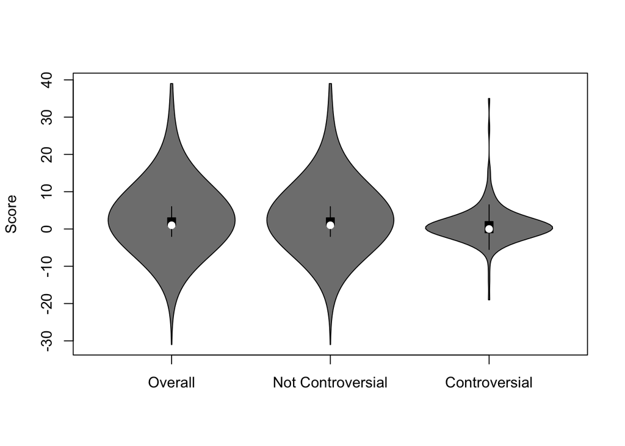

```r
vioplot(
  score[abs(score)<40],
  score[controversiality==0 & abs(score)<40],
  score[controversiality==1 & abs(score)<40],
  names=c("Overall", "Not Controversial", "Controversial"),
  ylab = "Score")
```

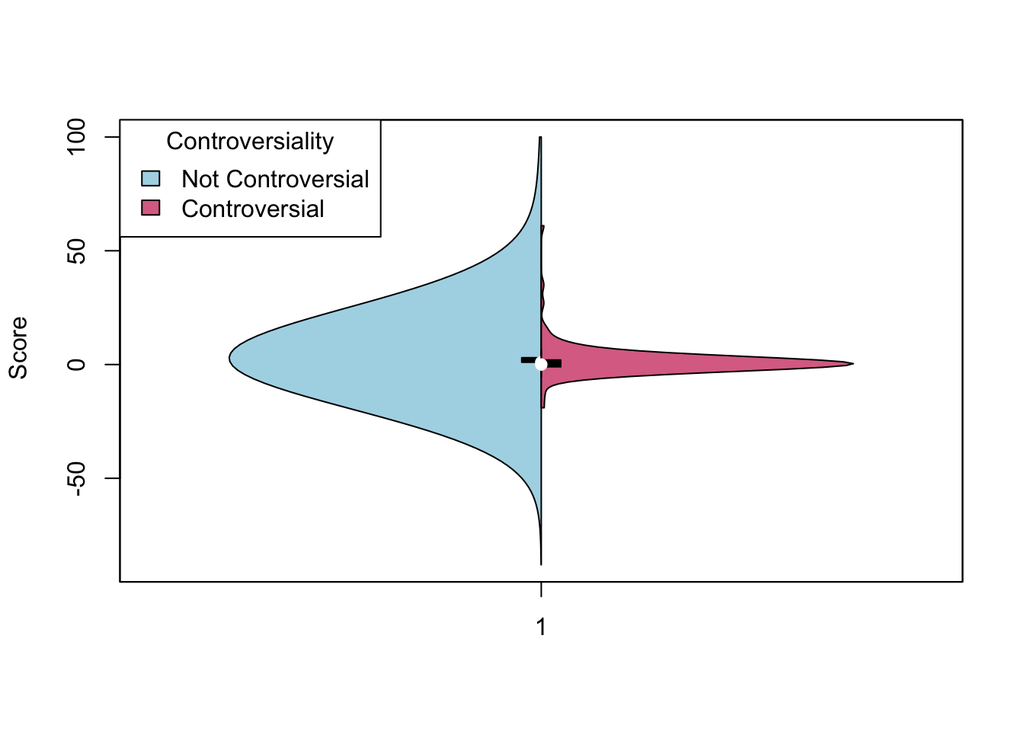

```r
vioplot(score[controversiality==0 & abs(score) <= 100], col = "lightblue", side="left", ylab = " Score")
vioplot(score[controversiality==1& abs(score) <= 100], col = "palevioletred", side="right", add=TRUE)
legend("topleft", fill = c("lightblue", "palevioletred"), legend = c("Not Controversial", "Controversial"), title = "Controversiality")
```

#### Score vs Contr. Histogram? (may not include this one, depends)

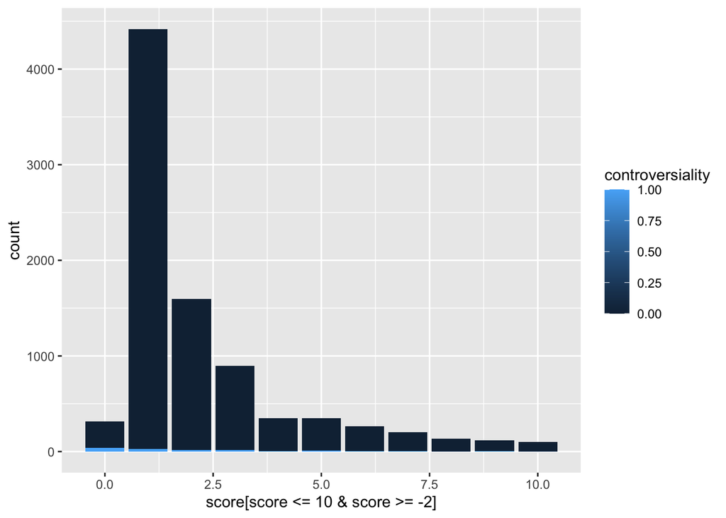

```r
library(ggplot2)

comments.df[score>=0 & score<=10, ] %>%
  group_by(score, controversiality) %>%
  ggplot(aes(x = score[score<=10 & score >=-2], group = controversiality, fill = controversiality)) +
  geom_bar(stat = "count")
```

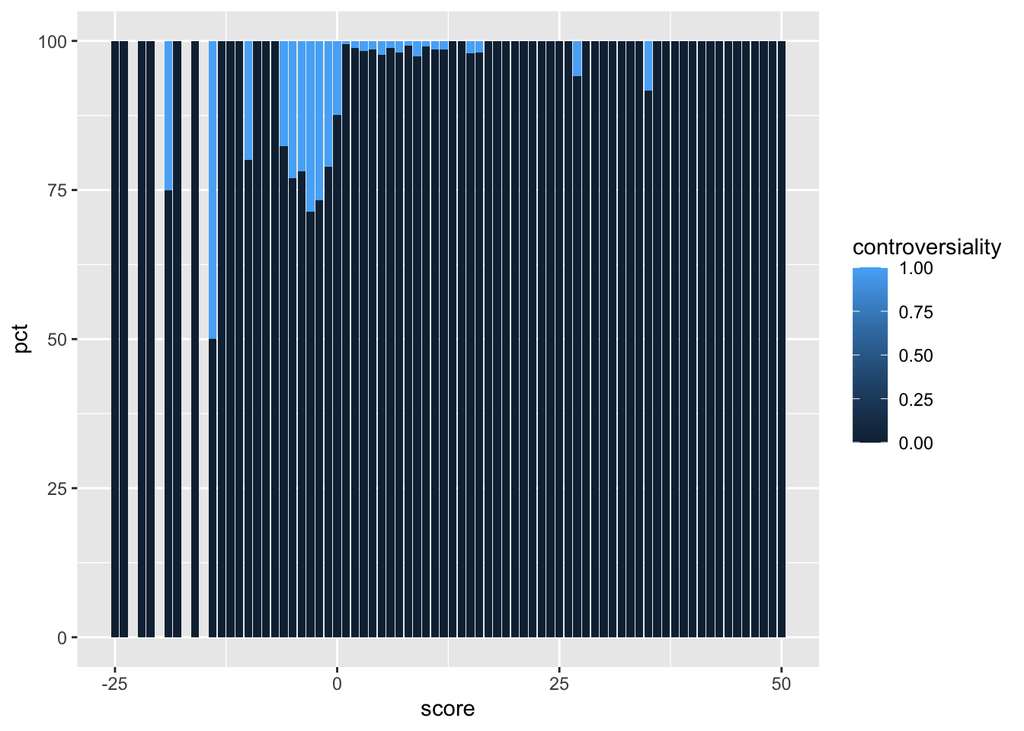

```r
comments.df[score <= 50 & score >= -25, ] %>%
  count(score, controversiality) %>%
  group_by(score) %>%
  mutate(pct=prop.table(n)*100) %>%
  ggplot() + aes(score, pct, fill=controversiality) +
  geom_bar(stat="identity" )
```

```r
search_function <-function(search_term){
greppyboy = c()
greppyboy <- grepl(search_term, not.deleted$body)
not.deleted$body[greppyboy]
}

search_function("incel")
```

```
## [1] "incels: the most fragile of all manchildren"
## [2] "well yes but I'm talking about the retards here that are like 17 and claim to be incel, fucking lol at these literal children"
## [3] "Just another creeper from r/incel on fb, i wonder how their numbers seem to grow and grow despite the ya know celibacy part "
## [4] "Some are from r/incels. It means they didn't entirely give up hope, but their toxic ways show sometimes."
```

```r
library(tm)
```

```r
library(wordcloud)
all_words <-not.deleted$body[1:nrow(not.deleted)]

all_words <- Corpus(VectorSource(all_words))

all_words <- all_words %>%
  tm_map(removeNumbers) %>%
  tm_map(removePunctuation) %>%
  tm_map(stripWhitespace)
all_words <- tm_map(all_words, content_transformer(tolower))
all_words <- tm_map(all_words, removeWords, stopwords("english"))
dtm <- TermDocumentMatrix(all_words)
matrix <- as.matrix(dtm)
words <- sort(rowSums(matrix),decreasing=TRUE)
df <- data.frame(word = names(words),freq=words)

# words
## adapted from https://towardsdatascience.com/create-a-word-cloud-with-r-bde3e7422e8a
```

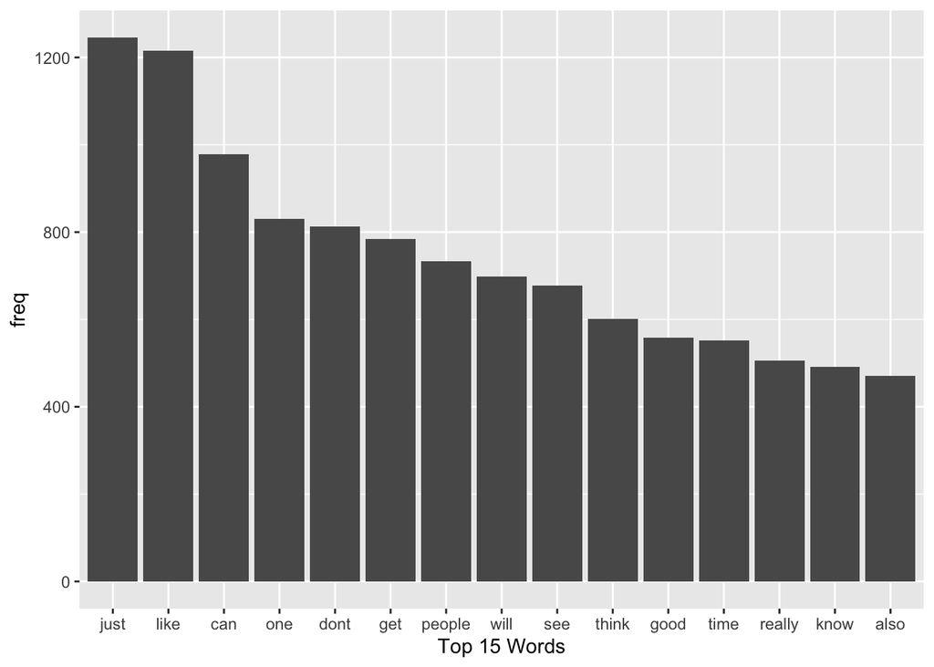

```r
top_words<- df[order(-df$freq),]
top15 <- top_words[1:15,]

ggplot(data=top15,aes(x=reorder(word,-freq), y=freq),) +
  geom_bar(stat="identity") +
  scale_x_discrete(name="Top 15 Words")
```

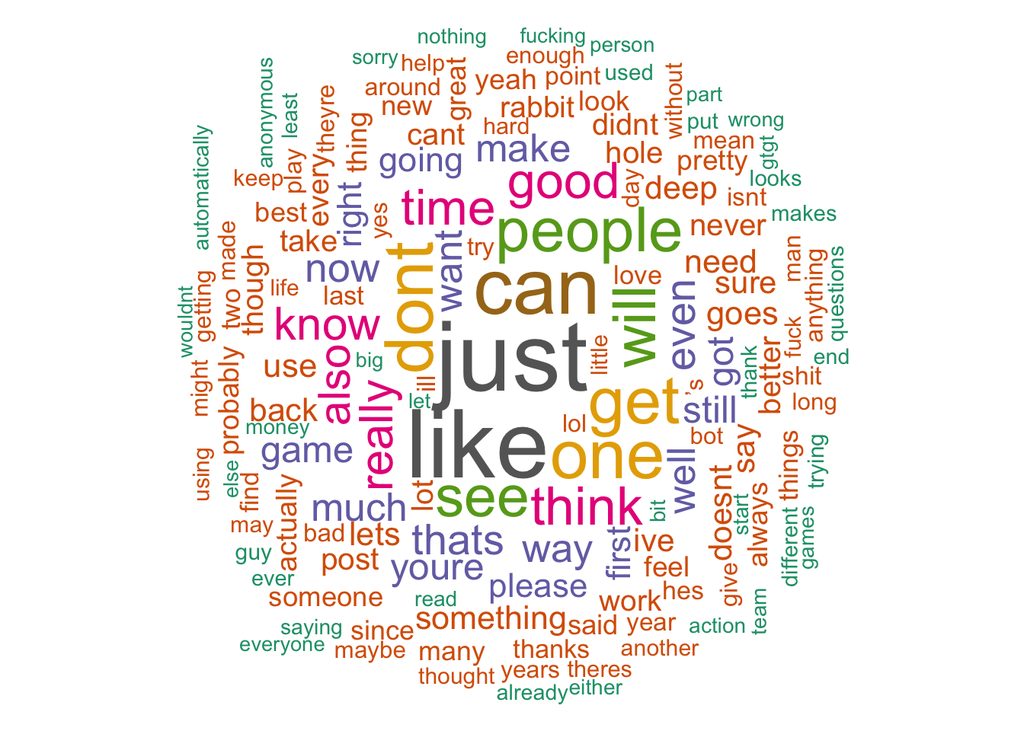

```r
set.seed(420666) # for reproducibility
wordcloud(words = df$word, freq = df$freq, min.freq = 3,
max.words=150, random.order=FALSE, rot.per=0.35,
colors=brewer.pal(8, "Dark2"))
```

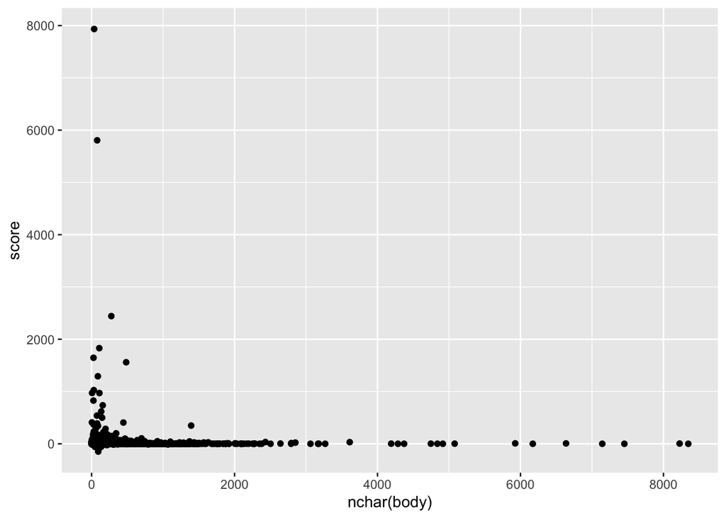

```r
ggplot(not.deleted, aes(nchar(body),score)) +
  geom_point()
```